# Intro to Stats and Regression from a Spreadsheet using R with a little bit of fun using units

Try executing each R “chunk” by clicking the *Run* button within the chunk or by placing your cursor inside it and pressing *Cmd+Shift+Enter*.

**Warning. Typos are Legion!**

# 1. Intro

The goal here is to demonstrate cracking open an excel spreadsheet in R and doing some basic stats.

# 2. Loading the Libraries

To work with R we will first have to load some libraries. This is like in C where you have the #include statement to do things like raise things to powers and stuf like that.

Some of these libaries or “packages” come with R. Others will have to be installed. They are indicatred here for this exercise.

- Install Us First
  - [moments](https://www.rdocumentation.org/packages/moments/versions/0.14) : This has a load of good stuff for data analysis and plotting, more than you will need here but get it anyway.
  - [readxl](https://www.rdocumentation.org/packages/readxl/versions/1.1.0) : part of the (tidyverse)[https://www.tidyverse.org] package suite for reading traditional excel spreadsheets. In the long-run you probably also want to install the tidyverse package suite anyway.
  - [beanplot](https://www.rdocumentation.org/packages/beanplot/versions/1.2) Allows you to plot what is called a “beanplot” which, like it’s cousin, the violin plot, shows nuances of a variables distribution (helpful when working with irregular distributions)

  (with respect to tidyverse, it seems to be the “new thing” in R and a lot of my colleagues are using it so I am jumping on the bandwagon becasue being a lemming is fun… martyrey but fun… ok not fun… But still there are a lot of neat tricks in the tidyverse group of packages that, while they have a high leraning curve, do make some tasks easiser. I will add an annex to this exdercise to show one example.)
- This should come with R, if not install ’em.
  - [MASS](https://www.rdocumentation.org/packages/MASS/versions/7.3-50) : Has a lot of resources for regression.
- Not officially needed for this activity but I’ll demonstrate how units can be used in R in this example
  - [udunits2](https://www.rdocumentation.org/packages/udunits2/versions/0.13) Provides simple bindings to Unidata’s udunits library for unit conversions (will be demonstrating but not explicity needing it here)
  - [units](https://www.rdocumentation.org/packages/units/versions/0.6-0)

```r
  # Data Handling Libraries

  library(package = "readxl")    # Read Excel Files

  # Statistics Libraries

  library(package = "moments")   # Moments, cumulants, skewness, kurtosis and related tests
  library(package = "MASS")      # Support Functions and Datasets for Venables & Ripley's MASS text

  # Graphics Libraries

  library(package = "beanplot")  # Visualization via Beanplots (like Boxplot/Stripchart/Violin Plot)

  # Data Processing Libraries

  library(package = "udunits2")  # Unit Conversion Support
  library(package = "units")     # Measurement Units for R Vectors
```

# 3. Cracking a Spreadsheet

The spreadsheet example below is a more complicated than what you hopefully have.

The original data is from a set of papers on Concrete by I-Cheng Yeh

- [Yeh, I-Cheng, “Modeling slump of concrete with fly ash and superplasticizer,” *Computers and Concrete*, **5**(6), 559-572, 2008. doi: 10.12989/cac.2008.5.6.559.](http://www.techno-press.org/content/?page=article&journal=cac&volume=5&num=6&ordernum=4)
- [Yeh, I-Cheng, “Simulation of concrete slump using neural networks,” *Construction Materials*, **162**(1), 11-18, 2009. doi: 10.1680/coma.2009.162.1.11](https://www.icevirtuallibrary.com/doi/10.1680/coma.2009.162.1.11)
- [Yeh, I-Cheng, “Prediction of workability of concrete using design of experiments for mixtures,” *Computers and Concrete*, **5**(1), 1-20, 2008. doi: 10.12989/cac.2008.5.1.001](http://www.techno-press.org/content/?page=article&journal=cac&volume=5&num=1&ordernum=1)
- [Yeh, I-Cheng, “Modeling slump flow of concrete using second-order regressions and artificial neural networks,” *Cement and Concrete Composites*, **29**(6), 474-480, 2007. doi: 10.1016/j.cemconcomp.2007.02.001](https://www.sciencedirect.com/science/article/pii/S0958946507000261?via%3Dihub)
- [Yeh, I-Cheng, “Exploring concrete slump model using artificial neural networks,” *ASCE J. of Computing in Civil Engineering*, **20**(3), 217-221, 2006. doi: 10.1061/(ASCE)0887-3801(2006)20:3(217)](https://ascelibrary.org/doi/10.1061/%28ASCE%290887-3801%282006%2920%3A3%28217%29)

and is kept at the [UC-Irvine Machine Learning Repository](https://archive.ics.uci.edu/ml/datasets/Concrete+Slump+Test).

It can be found here at http://kyrill.ias.sdsmt.edu/cee_284/Base_Concrete_Slump_Test_for_R.xlsx

The relevant page and screenshot is below. For drama-free R import you are probably best off keeping a page on your spreadsheet file that is very simple, with numbers going down, and a single line for Row-1 with the headers of each column. If you want to get fancy on other pages that you’d turn in as tables in reports, you can do that on another spreadsheet page.

[figure not shown]

Concrete Spreadsheet Screenshot

To crack open the spreadhseet we will want to use the read_excel function.

You can read the spreadsheet from a local drive or from a website.

```r
  # you will need the full path to the file you are using (either online or locally on your disk)

  spreadsheet_name     = "~/Dropbox/Base_Concrete_Slump_Test_for_R.xlsx"

  # in case it is a URL location you need to download it
  # otherwise comment this indented section out

      spreadsheet_location = "http://kyrill.ias.sdsmt.edu/cee_284/Base_Concrete_Slump_Test_for_R.xlsx"

      download.file(url      = spreadsheet_location, # URL location
                    destfile =     spreadsheet_name) # local downloaded location

      remove(spreadsheet_location) # clean up variables

  # this command will read the file

  concrete = read_excel(path      = spreadsheet_name, # local spreadsheet location
                        sheet     =           "Data", # page of spreadsheet
                        col_names =             TRUE) # first row are the column headers

  remove(spreadsheet_name) # clean up variables
```

With the data read in we can now look at the table of the data. This looks much nicer when working in R Notebooks instead of Plain Ordinary R

```r
  # Print data frame

  print(concrete)
```

```
## # A tibble: 103 x 11
##    `Test Number` Cement  Slag Fly_Ash Water Superplasticizer
##            <dbl>  <dbl> <dbl>   <dbl> <dbl>            <dbl>
##  1             1    273    82     105   210                9
##  2             2    163   149     191   180               12
##  3             3    162   148     191   179               16
##  4             4    162   148     190   179               19
##  5             5    154   112     144   220               10
##  6             6    147    89     115   202                9
##  7             7    152   139     178   168               18
##  8             8    145     0     227   240                6
##  9             9    152     0     237   204                6
## 10            10    304     0     140   214                6
## # ... with 93 more rows, and 5 more variables: Coarse_Aggregates <dbl>,
## #   Fine_Aggregates <dbl>, Slump <dbl>, Flow <dbl>,
## #   Compressive_Strength_28dy <dbl>
```

### Extra: Units

*Dang. I like units. I don’t see any. I’m anal and have learned that adding as much descriptive data early on in processing your dataset will make people (and most importantly, yourself) not hate you at a later date. So I am adding them here with the set_units function. This will add units as an attribute.

```r
concrete$Cement                    = set_units(x     = concrete$Cement,
                                               value = "kg m-3")
concrete$Slag                      = set_units(x     = concrete$Slag,
                                               value = "kg m-3")
concrete$Fly_Ash                   = set_units(x     = concrete$Fly_Ash,
                                               value = "kg m-3")
concrete$Water                     = set_units(x     = concrete$Water,
                                               value = "kg m-3")
concrete$Superplasticizer          = set_units(x     = concrete$Superplasticizer,
                                               value = "kg m-3")
concrete$Coarse_Aggregates         = set_units(x     = concrete$Coarse_Aggregates,
                                               value = "kg m-3")
concrete$Fine_Aggregates           = set_units(x     = concrete$Fine_Aggregates,
                                               value = "kg m-3")
concrete$Slump                     = set_units(x     = concrete$Slump,
                                               value = "cm")
concrete$Flow                      = set_units(x     = concrete$Flow,
                                               value = "cm")
concrete$Compressive_Strength_28dy = set_units(x     = concrete$Compressive_Strength_28dy,
                                               value = "MPa")

  print(concrete)
```

```
## # A tibble: 103 x 11
##    `Test Number`   Cement     Slag  Fly_Ash    Water Superplasticizer
##            <dbl> <[kg/m^> <[kg/m^> <[kg/m^> <[kg/m^>       <[kg/m^3]>
##  1             1      273       82      105      210                9
##  2             2      163      149      191      180               12
##  3             3      162      148      191      179               16
##  4             4      162      148      190      179               19
##  5             5      154      112      144      220               10
##  6             6      147       89      115      202                9
##  7             7      152      139      178      168               18
##  8             8      145        0      227      240                6
##  9             9      152        0      237      204                6
## 10            10      304        0      140      214                6
## # ... with 93 more rows, and 5 more variables:
## #   Coarse_Aggregates <[kg/m^3]>, Fine_Aggregates <[kg/m^3]>,
## #   Slump <[cm]>, Flow <[cm]>, Compressive_Strength_28dy <[MPa]>
```

If you click in the Global Environment Box, those units aren’t arbitrary strings.

Better Still, the same command of set_units when applied to a variable that already has units will convert it. This is nice when moving between SI units, USCS units. If you are going to be cheeky and try the Furlong/Furkin/Fortnight system (FFF), alas that while the udunits2 package in R recognizes all three units, it recognizes firkins as a volume measure (which is really is) and not the mass measure based on density of water.

Example here:

```r
  strength_in_psi = set_units(x     = concrete$Compressive_Strength_28dy,
                                               value = "psi")
  print(concrete$Compressive_Strength_28dy[1])
```

```
## 34.99 MPa
```

```r
  print(strength_in_psi[1])
```

```
## 5074.87 psi
```

```r
  # Ok now I'm being silly but so were the package developers.  Blame them.

  cement_in_slug_per_cu3 = set_units(x    = concrete$Cement,
                                            value = "slugs/furlongs^3")

  print(concrete$Cement[1])
```

```
## 273 kg/m^3
```

```r
  print(cement_in_slug_per_cu3[1])
```

```
## 152289718 slugs/furlongs^3
```

```r
  # cleaning-up our horseplay..

  remove(strength_in_psi)
  remove(cement_in_slug_per_cu3)
```

If you need your units and want to mimimize “messy” code in R when it conflicts any given function. You can later strip out units by using the [as.numeric()](https://www.rdocumentation.org/packages/base/versions/3.5.1/topics/numeric) function

or if you are working with a large frame and need to do them all at once, there is the “funcky” command set below.

Here I am copying my “unit’ed” values to a new dataframe name and then stripping out the units below using the [lapply()](https://www.rdocumentation.org/packages/base/versions/3.5.1/topics/lapply) function

```r
# retaining a unit-friendly copy

concrete_with_units = concrete

# stripping out units

concrete    = lapply(concrete_with_units,
                     function(x)
                              as.numeric(sub("\\s+\\D+$", "", x))
                     )
```

# 4. Some Basic Statistics and Traditional Single Variable Plots

Lets start with some basic statistics and plotting of them.

## 4.a. The “classic” stats

Let’s get the mom-and-apple-pie stats for Concrete That second argument allows you to deal with missing data.

(for any people wanting to do Unit-Fu, note below that these functions will allow you to use units but not all will recognize them when done)

```r
  mean(x     = concrete_with_units$Cement, # variable to crunch
       na.rm =                       TRUE) # ignore msissing data
```

```
## 229.8942 kg/m^3
```

```r
  sd(x     = concrete_with_units$Cement, # variable to crunch
     na.rm =                       TRUE) # ignore msissing data
```

```
## [1] 78.87723
```

```r
  skewness(x     = concrete_with_units$Cement, # variable to crunch
           na.rm =                       TRUE) # ignore msissing data
```

```
## [1] 0.1430181
```

```r
  kurtosis(x     = concrete_with_units$Cement, # variable to crunch
           na.rm =                       TRUE) # ignore msissing data
```

```
## [1] 1.334484
```

Same for Water

```r
  mean(x     = concrete_with_units$Water,       # variable to crunch
       na.rm =                      TRUE)       # ignore msissing data
```

```
## 197.168 kg/m^3
```

```r
  sd(x     = concrete_with_units$Water,         # variable to crunch
     na.rm =                      TRUE)         # ignore msissing data
```

```
## [1] 20.20816
```

```r
  skewness(x     = concrete$Water,   # variable to crunch
           na.rm =            TRUE)  # ignore msissing data
```

```
## [1] 0.2596788
```

```r
  kurtosis(x     = concrete$Water,   # variable to crunch
           na.rm =            TRUE)  # ignore msissing data
```

```
## [1] 2.187334
```

Finally the basic stats for Compressive Strength

```r
  mean(x     = concrete$Compressive_Strength_28dy, # variable to crunch
       na.rm =                               TRUE) # ignore msissing data
```

```
## [1] 36.03942
```

```r
  sd(x     = concrete$Compressive_Strength_28dy, # variable to crunch
     na.rm =                               TRUE) # ignore msissing data
```

```
## [1] 7.838232
```

```r
  skewness(x     = concrete$Compressive_Strength_28dy, # variable to crunch
           na.rm =                               TRUE) # ignore msissing data
```

```
## [1] 0.1894236
```

```r
  kurtosis(x     = concrete$Compressive_Strength_28dy, # variable to crunch
           na.rm =                               TRUE) # ignore msissing data
```

```
## [1] 3.135145
```

## 4.b. The Historgrams, Boxplots, etc.

R has a few ways to do the basic histograms, Boxplots and other distribution plots.

There are a number of spiffy ways to plot these statistical plots in R but these will give you “Maximum Satisfaction with Minimal Effort™️”

I’ll also stop using the units dataframe at this point since some of these functions (I’ll tell you which ones as we get to them don’t like having those units attributes)

For a histogram, command is “[hist()](https://www.rdocumentation.org/packages/graphics/versions/3.4.3/topics/hist)”

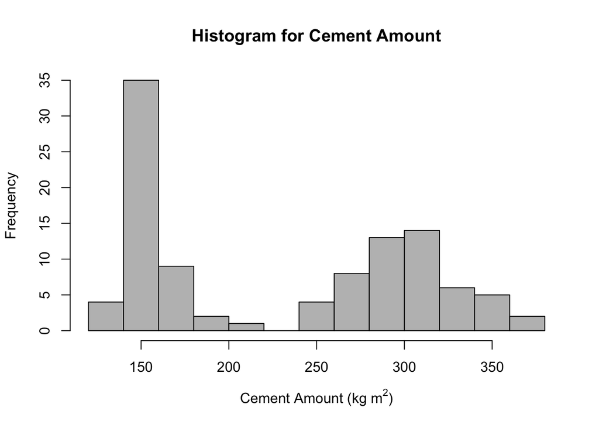

```r
# plotting histograms

hist(x      = concrete$Cement,                         # data to process
     breaks = 10,                                      # # of intervals
     main   = "Histogram for Cement Amount",           # main title string
     xlab   = expression('Cement Amount (kg m'^2*")"), # this lets us use superscripts/subscripts
     col    = "grey",                                  # color for shading
     border = "black")                                 # border for shading
```

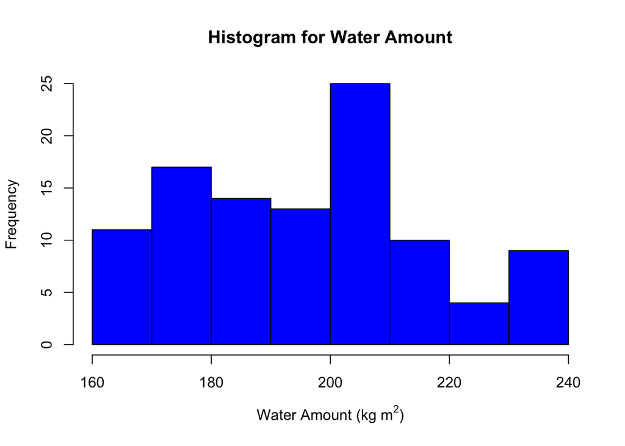

```r
hist(x      = concrete$Water,                         # data to process
     breaks = 10,                                     # # of intervals
     main   = "Histogram for Water Amount",           # main title string
     xlab   = expression('Water Amount (kg m'^2*")"), # x axis label
     col    = "blue",                                 # color for shading
     border = "black")                                # border for shading
```

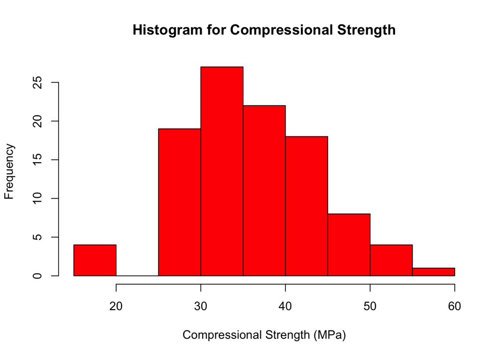

```r
hist(x      = concrete$Compressive_Strength_28dy,     # data to process
     breaks = 10,                                     # # of intervals
     main   = "Histogram for Compressional Strength", # main title string
     xlab   = "Compressional Strength (MPa)",         # x axis label
     col    = "red",                                  # color for shading
     border = "black")                                # border for shading
```

And here are box plots

*(the R boxplot function doesn’t play nice with units)*

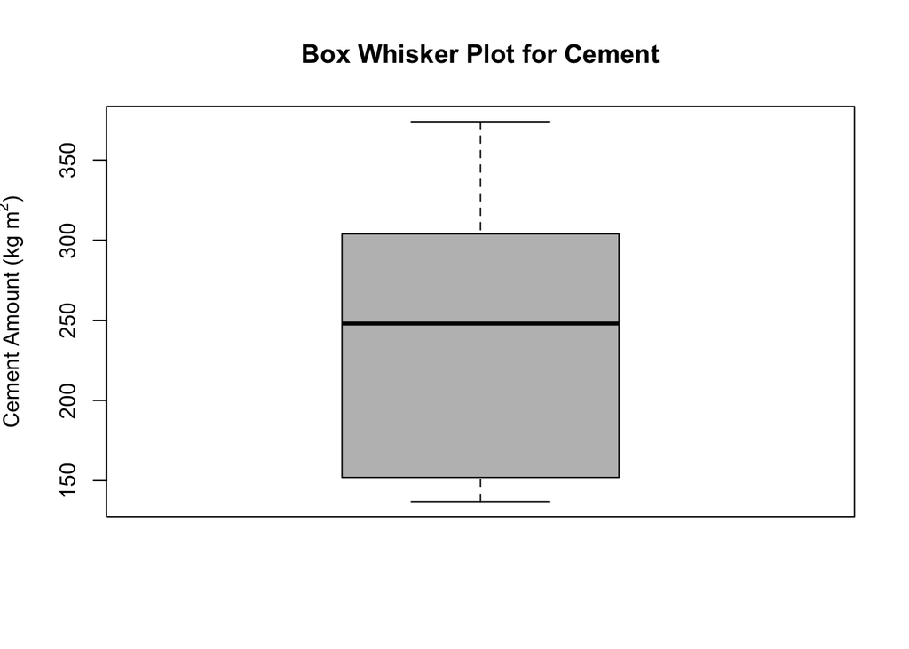

```r
# plotting box plots

boxplot(x    = concrete$Cement,                         # data to process
        main = "Box Whisker Plot for Cement",           # main title string
        ylab = expression('Cement Amount (kg m'^2*")"), # y axis label
         col = "grey",                                  # color for shading
      border = "black")                                 # color for borders
```

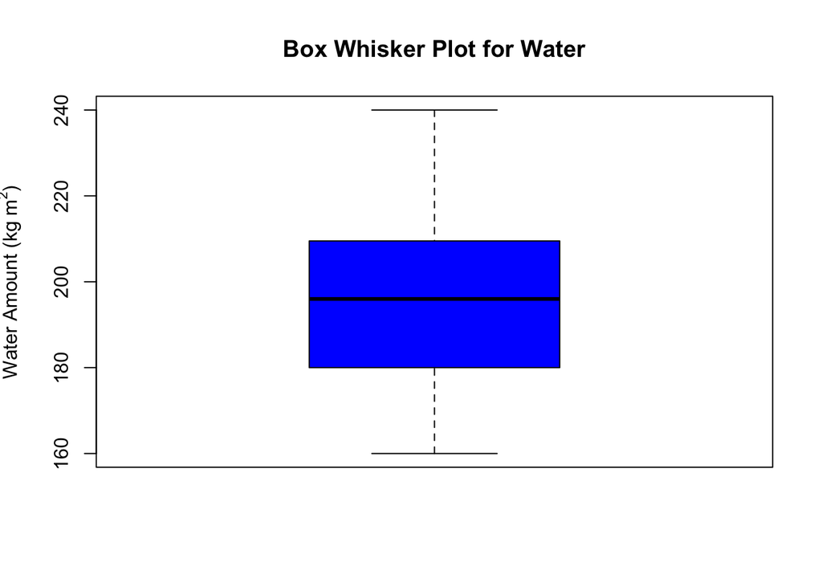

```r
boxplot(   x =  concrete$Water ,                        # data to process
        main = "Box Whisker Plot for Water",            # main title string
        ylab = expression('Water Amount (kg m'^2*")"),  # y axis label
         col = "blue",                                  # color for shading
      border = "black")                                 # color for borders
```

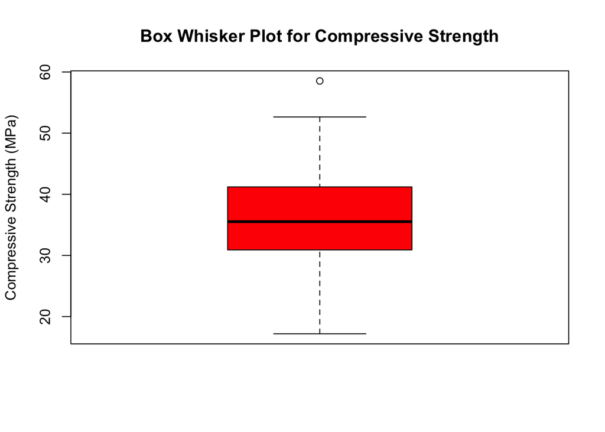

```r
boxplot(   x = concrete$Compressive_Strength_28dy,             # data to process
        main = "Box Whisker Plot for Compressive Strength",    # main title string
        ylab = "Compressive Strength (MPa)",                   # y axis label
         col = "red",                                          # color for shading
      border = "black")                                        # color for borders
```

With these we of course see a major limitation in box-whisker plots. We don’t, for example, see the bimodal nature of the Concrerte data. It would be nice to see a variant of the box-wisker that gives is the “looking-down” on the histogram advangtate of the box whsiker with the ability to see “nuance” of various features of the histogram.

Luckilly lots people have and a blessed few have invested the time to write code to mae this happen. There are two major kinds of “alterantive” plots out there. The “Violin Plot” (not my favorite of the two) is one but I prefer the [beanplot()](https://www.rdocumentation.org/packages/beanplot/versions/1.2/topics/beanplot).

*(likewise with boxplots, this one doesn’t like units )*

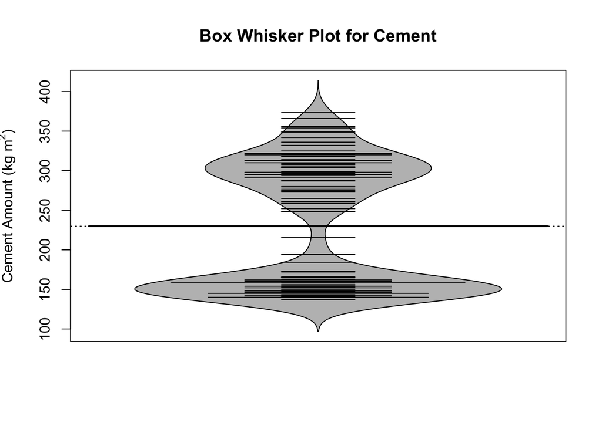

```r
# plotting box plots

beanplot(  x =  concrete$Cement,                        # data to process
        main = "Box Whisker Plot for Cement",           # main title string
        ylab = expression('Cement Amount (kg m'^2*")"), # y axis label
         col = "grey",                                  # color for shading
      border = "black")                                 # color for borders
```

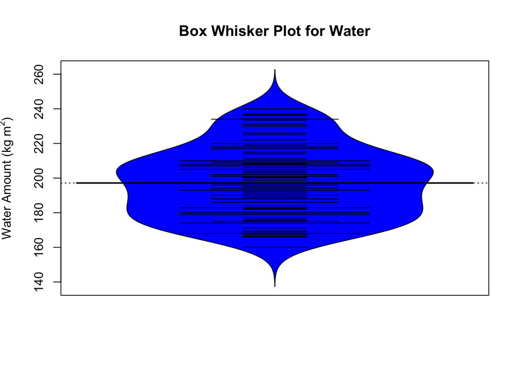

```r
beanplot(  x = concrete$Water,                          # data to process
        main = "Box Whisker Plot for Water",            # main title string
        ylab = expression('Water Amount (kg m'^2*")"),  # y axis label
         col = "blue",                                  # color for shading
      border = "black")                                 # color for borders
```

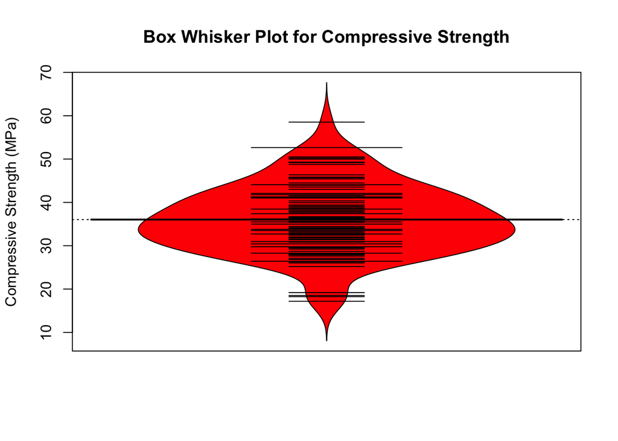

```r
beanplot(  x =  concrete$Compressive_Strength_28dy ,           # data to process
        main = "Box Whisker Plot for Compressive Strength",    # main title string
        ylab = "Compressive Strength (MPa)",                   # y axis label
         col = "red",                                          # color for shading
      border = "black")                                        # color for borders
```